# Homework: Text classification

Anna Tedikova

31 10 2022

First, load the data.

```r
data <- read_csv("C:/Users/Anna/Desktop/Corona_NLP_train.csv")
head(data)
```

```
## # A tibble: 6 x 6
##   UserName ScreenName Location                 TweetAt    OriginalTweet  Senti~1
##      <dbl>      <dbl> <chr>                    <chr>      <chr>          <chr>
## 1     3799      48751 London                   16-03-2020 "@MeNyrbie @P~ Neutral
## 2     3800      48752 UK                       16-03-2020 "advice Talk ~ Positi~
## 3     3801      48753 Vagabonds                16-03-2020 "Coronavirus ~ Positi~
## 4     3802      48754 <NA>                     16-03-2020 "My food stoc~ Positi~
## 5     3803      48755 <NA>                     16-03-2020 "Me, ready to~ Extrem~
## 6     3804      48756 UT: 36.319708,-82.363649 16-03-2020 "As news of t~ Positi~
## # ... with abbreviated variable name 1: Sentiment
```

## 1. Text Preprocessing

Here we prepare data for tokenization, exclude neutral tweets, and add column doc_id.

```r
data <- data %>% mutate(OriginalTweet = stri_replace_all_regex(OriginalTweet,
                                  pattern=c("\u0091", "\u0092", "\u0093", "\u0094", "\u0095", "\u0096", "\u0097", "\u0099", "\u0080", "\u0084", "\u009e", "\u009a"),
                                  replacement=c("'", "'", "'", "'", "", "", "", "", "", "", "", ""),
                                  vectorize=FALSE))

data_pn <- data %>% filter(Sentiment != "Neutral") %>% mutate(sent_posneg = recode(Sentiment,
  "Extremely Positive" = "positive",
  "Positive" = "positive",
  .default = "negative"))  %>%
  select(OriginalTweet, sent_posneg)

data_pn <- data_pn %>% mutate(doc_id = row_number())

head(data_pn)
```

```
## # A tibble: 6 x 3
##   OriginalTweet                                                   sent_~1 doc_id
##   <chr>                                                           <chr>    <int>
## 1 "advice Talk to your neighbours family to exchange phone numbe~ positi~      1
## 2 "Coronavirus Australia: Woolworths to give elderly, disabled d~ positi~      2
## 3 "My food stock is not the only one which is empty...\r\r\n\r\r~ positi~      3
## 4 "Me, ready to go at supermarket during the #COVID19 outbreak.\~ negati~      4
## 5 "As news of the region's first confirmed COVID-19 case came ou~ positi~      5
## 6 "Cashier at grocery store was sharing his insights on #Covid_1~ positi~      6
## # ... with abbreviated variable name 1: sent_posneg
```

Then we proceed to preprocessing the subset data: exclude stopwords, tokenize the tweets - splitting them into units appropriate for analysis. Finally, we lemmatize tokens. The word may have different forms of it but duplicates of the same word will not be informative to us so we create lemmas that reduce different forms of one word to one form. We also delete punctuation and numbers.

```r
data_pn$text_clean <- iconv(data_pn$OriginalTweet, "UTF-8", "UTF-8", sub = '')
data_pn$text_clean <- gsub("[[:punct:]]", " ", data_pn$text_clean)
enstopwords <- tibble(word = stopwords("en"))
tweets_tok <- unnest_tokens(data_pn, word, text_clean, token = "tweets")

data_lemmas <- tweets_tok %>%
    mutate(lem = lemmatize_words(word)) %>%
    filter(! lem %in% stopwords("en")) %>%
    filter(! str_detect(lem, "[0-9]+"))

kable(head(data_lemmas))
```

| OriginalTweet | sent_posneg | doc_id | word | lem |
| --- | --- | --- | --- | --- |
| advice Talk to your neighbours family to exchange phone numbers create contact list with phone numbers of neighbours schools employer chemist GP set up online shopping accounts if poss adequate suppli… | positive | 1 | advice | advice |
| advice Talk to your neighbours family to exchange phone numbers create contact list with phone numbers of neighbours schools employer chemist GP set up online shopping accounts if poss adequate suppli… | positive | 1 | talk | talk |
| advice Talk to your neighbours family to exchange phone numbers create contact list with phone numbers of neighbours schools employer chemist GP set up online shopping accounts if poss adequate suppli… | positive | 1 | neighbours | neighbour |
| advice Talk to your neighbours family to exchange phone numbers create contact list with phone numbers of neighbours schools employer chemist GP set up online shopping accounts if poss adequate suppli… | positive | 1 | family | family |
| advice Talk to your neighbours family to exchange phone numbers create contact list with phone numbers of neighbours schools employer chemist GP set up online shopping accounts if poss adequate suppli… | positive | 1 | exchange | exchange |
| advice Talk to your neighbours family to exchange phone numbers create contact list with phone numbers of neighbours schools employer chemist GP set up online shopping accounts if poss adequate suppli… | positive | 1 | phone | phone |

## 2. EDA

First, we need to create a frequency list of our lemmas.

```r
freqlist <- data_lemmas %>% count(lem, sort=TRUE)
kable(head(freqlist))
```

| lem | n |
| --- | --- |
| t | 23319 |
| co | 18589 |
| https | 18448 |
| coronavirus | 14367 |
| covid | 12693 |
| price | 7762 |

Next, we count total size of the corpus (all lemmas) and vocabulary size (distinct lemmas).

```r
sum(freqlist$n)
```

```
## [1] 708739
```

```r
data_lemmas %>% distinct(lem) %>% nrow
```

```
## [1] 40744
```

We can see that there are les unique lemmas, so some of them are repeated thoughout the corpus.

### Class distribution

We make a table with counts of lemmas in positive and negative corpuses. It seems that the negative corpus is smaller, but the difference is not great.

```r
kable(table(data_lemmas$sent_posneg),
      col.names = c("Sentiment", "Freq"))
```

| Sentiment | Freq |
| --- | --- |
| negative | 322903 |
| positive | 385836 |

To make data for comparisons, we now create lemma frequency lists for 2 types of sentiments. Filter out rare words (n <= 10 for both types).

```r
posneg.lemmas <- data_lemmas %>%
    dplyr::count(lem, sent_posneg) %>%
    spread(sent_posneg, n, fill = 0) %>%
    dplyr::filter(positive > 10 | negative > 10)
kable(head(posneg.lemmas))
```

| lem | negative | positive |
| --- | --- | --- |
| ab | 11 | 4 |
| abandon | 14 | 1 |
| abc | 21 | 10 |
| abcnews | 23 | 10 |
| ability | 12 | 36 |
| able | 144 | 213 |

We can use G2 and logratios for each type to try and see the difference in words used.

```r
g2 = function(a, b) {
  c = sum(a)
  d = sum(b)
  E1 = c * ((a + b) / (c + d))
  E2 = d * ((a + b) / (c + d))
  return(2*((a*log(a/E1+1e-7)) + (b*log(b/E2+1e-7))))
}
```

Now we can calculate log-likelihood for lemma frequency differences for each type of sentiment:

```r
emotion.g2 <- posneg.lemmas %>%
    mutate(g2=g2(positive, negative)) %>%
    arrange(desc(g2)) %>%
    mutate(g2 = round(g2, 2))
kable(head(emotion.g2))
```

| lem | negative | positive | g2 |
| --- | --- | --- | --- |
| panic | 2154 | 465 | 1502.11 |
| hand | 417 | 2193 | 1029.96 |
| crisis | 1355 | 305 | 917.38 |
| help | 446 | 2057 | 857.23 |
| thank | 164 | 1228 | 742.18 |
| sanitizer | 492 | 1978 | 712.99 |

#### Effect size. Log Ratio

So we are going to supplement our log-likelihood tests with an effect size measure that allow to quantify, how large exactly is the difference of frequencies.

Here we define a function similar to g2, and apply it to our data.

```r
logratio <- function(a, b) {
    return(log2((a/sum(a)/(b/sum(b)))))
}
```

Now we may add odds to our table.

```r
emotion.lr <- emotion.g2 %>%
    mutate(logodds = logratio(positive, negative))
```

```r
head(emotion.lr) %>%
    arrange(abs(logodds))
```

```
## # A tibble: 6 x 5
##   lem       negative positive    g2 logodds
##   <chr>        <dbl>    <dbl> <dbl>   <dbl>
## 1 sanitizer      492     1978  713.    1.75
## 2 help           446     2057  857.    1.95
## 3 hand           417     2193 1030.    2.14
## 4 crisis        1355      305  917.   -2.41
## 5 panic         2154      465 1502.   -2.47
## 6 thank          164     1228  742.    2.65
```

Words most acutely overused in tweets of one or another sentiment:

```r
emotion.disproportion <- emotion.lr %>%
    dplyr::filter(positive > 0 & negative > 0) %>%
    group_by(logodds < 0) %>%
    top_n(15, abs(logodds)) %>%
    ungroup()
kable(head(emotion.disproportion))
```

| lem | negative | positive | g2 | logodds | logodds < 0 |
| --- | --- | --- | --- | --- | --- |
| crude | 174 | 12 | 199.14 | -4.114503 | TRUE |
| arrest | 110 | 7 | 128.43 | -4.230527 | TRUE |
| threaten | 76 | 4 | 92.57 | -4.504450 | TRUE |
| blame | 75 | 4 | 91.11 | -4.485341 | TRUE |
| bonus | 3 | 71 | 65.97 | 4.308262 | FALSE |
| safely | 4 | 70 | 60.31 | 3.872761 | FALSE |

The same result in a plot.

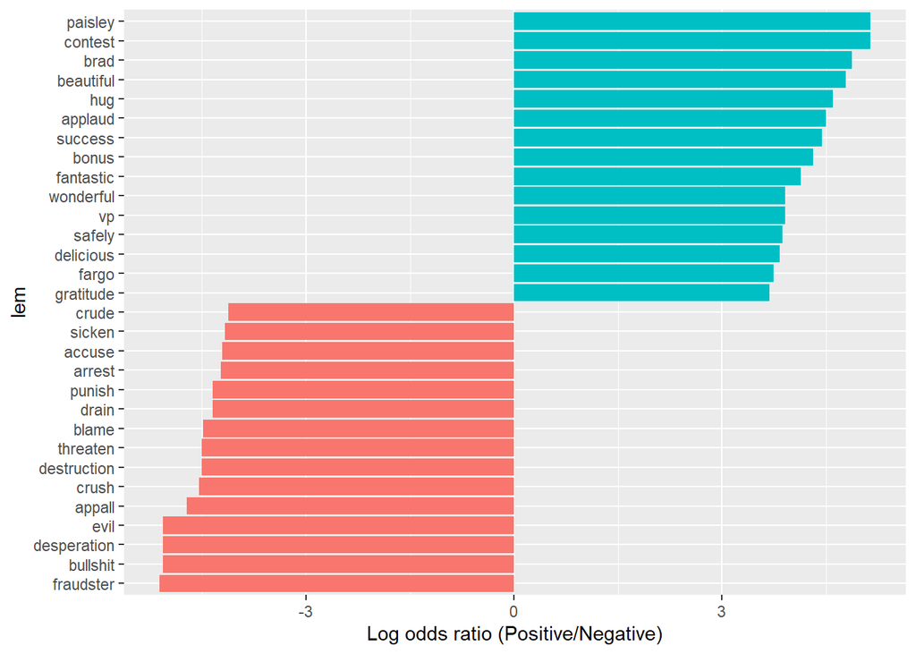

```r
emotion.lr %>%
    filter(positive > 0 & negative > 0) %>%
    group_by(logodds < 0) %>%
    top_n(15, abs(logodds)) %>%
    ungroup() %>%
    mutate(lem = reorder(lem, logodds)) %>%
    ggplot(aes(lem, logodds, fill = logodds > 0)) +
    geom_col(show.legend = FALSE) +
    coord_flip() +
    ylab("Log odds ratio (Positive/Negative)") +
    scale_fill_discrete(name = "", labels = c("Positive", "Negative"))
```

We can see in the plot some characteristic words: in negative tweets there are swear words (bullshit) or ones that denote bad things (destruction, desperation), whilst in positive there are words denoting something good (beautiful, success, hug).

## 3. Preparing data for classification

First, we calculate lemmas frequency in docs.

```r
lem_count <- data_lemmas%>% count(lem, doc_id, sort=TRUE)
```

Then, calculate TF-IDF.

```r
tfidf <- lem_count %>%
    bind_tf_idf(lem, doc_id, n)
kable(head(tfidf))
```

| lem | doc_id | n | tf | idf | tf_idf |
| --- | --- | --- | --- | --- | --- |
| gt | 6264 | 11 | 0.2820513 | 5.042349 | 1.4222011 |
| gt | 26750 | 9 | 0.3214286 | 5.042349 | 1.6207551 |
| online | 27635 | 9 | 0.3214286 | 2.597188 | 0.8348105 |
| thank | 30645 | 9 | 0.2903226 | 3.270856 | 0.9496032 |
| gt | 19386 | 8 | 0.2285714 | 5.042349 | 1.1525370 |
| expert | 26060 | 7 | 0.2592593 | 4.953796 | 1.2843174 |

Next we look if there are words with zero TF-IDF (if yes, drop them to reduce the corpus size for faster analysis).

```r
tfidf %>% filter(tf_idf<=0)
```

There are no such words, so we proceed with the current corpus.

We build a matrix with the frequencies as values.

```r
head(tfidf) %>%
    cast_dfm(doc_id, lem, n)
```

```
## Document-feature matrix of: 6 documents, 4 features (75.00% sparse) and 0 docvars.
##        features
## docs    gt online thank expert
##   6264  11      0     0      0
##   26750  9      0     0      0
##   27635  0      9     0      0
##   30645  0      0     9      0
##   19386  8      0     0      0
##   26060  0      0     0      7
```

Build the doc-term matrix - we will build the sparse matrix (this is just more optimized way for representing the matrix with many zeros).

```r
dfm <- tfidf %>%
    cast_dfm(doc_id, lem, tf_idf)
head(dfm)
```

```
## Document-feature matrix of: 6 documents, 40,744 features (99.95% sparse) and 0 docvars.
##        features
## docs          gt    online     thank   expert industry pray s senator wena amp
##   6264  1.422201 0         0         0               0    0 0       0    0   0
##   26750 1.620755 0         0         0               0    0 0       0    0   0
##   27635 0        0.8348105 0         0               0    0 0       0    0   0
##   30645 0        0         0.9496032 0               0    0 0       0    0   0
##   19386 1.152537 0         0         0               0    0 0       0    0   0
##   26060 0        0         0         1.284317        0    0 0       0    0   0
## [ reached max_nfeat ... 40,734 more features ]
```

```r
dfm_count <- tfidf %>%
    filter(tf_idf>0) %>%
    cast_dfm(doc_id, lem, n) %>%
    dfm_trim(min_termfreq=1, termfreq_type="count") %>%
    dfm_trim(min_docfreq=0.005, docfreq_type="prop")

head(dfm_count)
```

```
## Document-feature matrix of: 6 documents, 606 features (98.02% sparse) and 0 docvars.
##        features
## docs    gt online thank expert industry s amp bill can case
##   6264  11      0     0      0        0 0   0    0   0    0
##   26750  9      0     0      0        0 0   0    0   0    0
##   27635  0      9     0      0        0 0   0    0   0    0
##   30645  0      0     9      0        0 0   0    0   0    0
##   19386  8      0     0      0        0 0   0    0   0    0
##   26060  0      0     0      7        0 0   0    0   0    0
## [ reached max_nfeat ... 596 more features ]
```

In dfm matrix doc_ids are shuffled, so we select target classes according the order of doc ids in dfm matrix.

```r
emotion_labels <- data_lemmas$sent_posneg[as.integer(rownames(dfm_count))]
```

Next, we split our sample data into train set (90%) and test set (10%). We also fix random seed for reproducibility of the results.

```r
set.seed(1991)

split <- createDataPartition(y=emotion_labels, p = 0.9, list = FALSE)

train.data <- dfm_count %>% dfm_subset(rownames(dfm) %in% split)
test.data <- dfm_count %>% dfm_subset(!rownames(dfm) %in% split)

response <- as.factor(emotion_labels)
trainY <- response[split]
testY <- response[-split]

head(train.data)
```

```
## Document-feature matrix of: 6 documents, 606 features (98.02% sparse) and 0 docvars.
##        features
## docs    gt online thank expert industry s amp bill can case
##   6264  11      0     0      0        0 0   0    0   0    0
##   26750  9      0     0      0        0 0   0    0   0    0
##   27635  0      9     0      0        0 0   0    0   0    0
##   30645  0      0     9      0        0 0   0    0   0    0
##   19386  8      0     0      0        0 0   0    0   0    0
##   26060  0      0     0      7        0 0   0    0   0    0
## [ reached max_nfeat ... 596 more features ]
```

```r
head(test.data)
```

```
## Document-feature matrix of: 6 documents, 606 features (97.25% sparse) and 0 docvars.
##        features
## docs    gt online thank expert industry s amp bill can case
##   175    6      1     0      0        0 0   0    0   0    0
##   396    0      0     0      0        0 0   0    0   0    0
##   25687  0      0     0      0        0 1   0    0   0    0
##   9453   0      0     0      0        0 2   0    0   0    0
##   7367   0      0     0      0        0 0   0    0   1    0
##   12525  0      0     1      0        0 0   4    0   0    0
## [ reached max_nfeat ... 596 more features ]
```

We will use Naive Bayes which can only use the words that appear in train set during the prediction. So, we need to restrict the vocabulary of test set with the words that appear in train set.

```r
test.matched <- test.data %>%
    dfm_match(features = featnames(train.data))
```

## 4.Training the model

I decided to choose F1-score as the main metric for this model. It is calculated from 2other values - precision and recall, and I think that is why it is better to use this particular metric. Precision are true positive results divided by all positive results (even false ones), and recall are true positive results divided by all relevant results (true positives + false negatives). So by looking at F1-score we will see the share of true positive results among most of the results we will have which can give us more accurate understanding of the model.

There are binary features in our data set - in this case it is needed to convert the features to 0/1 (0-no such word in the doc, 1-word is in the doc).

Here we train our model on the train set.

```r
model.nb <- textmodel_nb(train.data, trainY, distribution = "multinomial")
summary(model.nb)
```

```
##
## Call:
## textmodel_nb.dfm(x = train.data, y = trainY, distribution = "multinomial")
##
## Class Priors:
## (showing first 2 elements)
## negative positive
##      0.5      0.5
##
## Estimated Feature Scores:
##                 gt   online    thank    expert industry       s      amp
## negative 0.0008192 0.005912 0.003019 0.0005149 0.001142 0.01462 0.009076
## positive 0.0008743 0.005483 0.002832 0.0004736 0.001066 0.01535 0.010323
##               bill     can     case essential    every     major     much
## negative 0.0005055 0.01049 0.001245  0.002411 0.001489 0.0005055 0.009788
## positive 0.0004645 0.01058 0.001207  0.002505 0.001544 0.0004599 0.010050
##             paper   price    staff     want     work    check    close      co
## negative 0.002359 0.01607 0.002181 0.002027 0.005402 0.001343 0.001994 0.03837
## positive 0.002477 0.01643 0.002095 0.001899 0.005606 0.001248 0.002240 0.03874
##            crisis     death       egg    fight    food     free      fuck
## negative 0.003628 0.0005804 0.0005149 0.001540 0.01403 0.001601 0.0007817
## positive 0.003315 0.0005464 0.0005055 0.001352 0.01370 0.001594 0.0007696
##                go
## negative 0.009446
## positive 0.009513
```

Then, we predict sentiment type for the docs from test set. We also calculate the probabilities of these predictions.

```r
predictedY <- predict(model.nb, newdata = test.matched)

predicted.prob <- round(predict(model.nb, newdata = test.matched, type = "prob"), 2)
```

### Evaluating model performance for positive sentiment

```r
cm.nb <- confusionMatrix(data = predictedY, reference = testY, positive="positive", mode = "prec_recall")
cm.nb
```

```
## Confusion Matrix and Statistics
##
##           Reference
## Prediction negative positive
##   negative      830      845
##   positive      819      849
##
##                Accuracy : 0.5022
##                  95% CI : (0.4851, 0.5193)
##     No Information Rate : 0.5067
##     P-Value [Acc > NIR] : 0.7041
##
##                   Kappa : 0.0045
##
##  Mcnemar's Test P-Value : 0.5400
##
##               Precision : 0.5090
##                  Recall : 0.5012
##                      F1 : 0.5051
##              Prevalence : 0.5067
##          Detection Rate : 0.2540
##    Detection Prevalence : 0.4990
##       Balanced Accuracy : 0.5023
##
##        'Positive' Class : positive
##
```

F1-score gives us a value of 0.5051 and we can see that is is a mean between precision and recall. This shows that about 50% of the data were classified as positive correctly. This is not a great result, because our model only correctly worked for have of the data.

### Evaluating model performance for negative sentiment

```r
cm.nb1 <- confusionMatrix(data = predictedY, reference = testY, positive ="negative", mode = "prec_recall")
cm.nb1
```

```
## Confusion Matrix and Statistics
##
##           Reference
## Prediction negative positive
##   negative      830      845
##   positive      819      849
##
##                Accuracy : 0.5022
##                  95% CI : (0.4851, 0.5193)
##     No Information Rate : 0.5067
##     P-Value [Acc > NIR] : 0.7041
##
##                   Kappa : 0.0045
##
##  Mcnemar's Test P-Value : 0.5400
##
##               Precision : 0.4955
##                  Recall : 0.5033
##                      F1 : 0.4994
##              Prevalence : 0.4933
##          Detection Rate : 0.2483
##    Detection Prevalence : 0.5010
##       Balanced Accuracy : 0.5023
##
##        'Positive' Class : negative
##
```

In case of negative sentiment F1-score is not that different - 0.4994. So again about 50% of the data was correctly classified as negative.

## 5. Analysis of predictors

We will use classifier for extracting the most important predictors to each class, similarly to how we earlier used g2 and logodds ratio to see most used words in each type of sentiment.

```r
vars.nb <- t(model.nb$param) %>%
    as.data.frame %>%
    rownames_to_column("word") %>%
    mutate(lo = log(positive/negative))
```

Most important predictors for class “positive”

```r
pred.pos <- vars.nb %>% arrange(desc(lo))
kable(head(pred.pos))
```

| word | negative | positive | lo |
| --- | --- | --- | --- |
| agree | 0.0002762 | 0.0004872 | 0.5677109 |
| russia | 0.0003745 | 0.0005829 | 0.4424231 |
| saudi | 0.0003136 | 0.0004508 | 0.3628467 |
| prevent | 0.0004728 | 0.0006785 | 0.3612453 |
| soap | 0.0005477 | 0.0007696 | 0.3401443 |
| confidence | 0.0003183 | 0.0004326 | 0.3067887 |

These words differ from the ones we got in plots in the EDA section. However, some are similar and also denote good things (opportunity, agree, wonder, nice, relief). So we can say that the classifier gives similar results in that the predictors are also words usually used positively.

Most important predictors for class “negative”

```r
pred.neg <- vars.nb %>% arrange(lo)
kable(head(pred.neg))
```

| word | negative | positive | lo |
| --- | --- | --- | --- |
| y | 0.0004868 | 0.0002778 | -0.5610975 |
| meal | 0.0004634 | 0.0002914 | -0.4638173 |
| alert | 0.0005055 | 0.0003233 | -0.4470319 |
| bottle | 0.0006881 | 0.0004690 | -0.3832841 |
| special | 0.0006319 | 0.0004326 | -0.3789784 |
| anything | 0.0005804 | 0.0004007 | -0.3705253 |

Those words also differ from the ones we got in plots in the EDA section. However, some are similar and also denote bad things (alert, difficult, struggle, die, drug). There are also some swear words, although they are closer to the middle of the list. So we can say that the classifier gives similar results in that the predictors are also words usually used negatively.

### Looking at the errors

Looking at the lists of predictors, there were some rather neutral words or even words that seemed more characteristic of the opposite type of sentiment. So, we may want to look at the examples where our model works not correctly

```r
predictions <- data.frame(doc_id=as.integer(rownames(predicted.prob)))
predictions$pred_y <- predictedY
predictions$pos_prob_pred <- predicted.prob[,1]
predictions$neg_prob_pred <- predicted.prob[,2]
predictions$true_label <- data_lemmas[rownames(predicted.prob),]$sent_posneg
predictions$text <- data_lemmas[rownames(predicted.prob),]$OriginalTweet
head(predictions)
```

```
##   doc_id   pred_y pos_prob_pred neg_prob_pred true_label
## 1    175 negative          0.51          0.49   negative
## 2    396 negative          0.59          0.41   positive
## 3  25687 positive          0.42          0.58   positive
## 4   9453 negative          0.56          0.44   positive
## 5   7367 negative          0.58          0.42   positive
## 6  12525 positive          0.33          0.67   negative
##                                                                                                                                                                                                                                                                                                          …
## 1                                    For corona prevention,we should stop to buy things with the cash and should use online payment methods because corona can spread through the notes. Also we should prefer online shopping from our home. It's time to fight against COVID 19?. #govindia #IndiaFight…
## 2 We have AMAZING CHEAP DEALS! FOR THE #COVID2019 going on to help you???\r\r\n#Trials\r\r\n#Monthly\r\r\n#Yearly \r\r\nAnd Resonable #Prices / #Subscriptions\r\r\nJust DM US! #bestiptv #iptv #Service #Iptv #iptvdeals #Cheap #ipTV #Football #HD #Movies #Adult #Cinema #hotmovies #iptvnew #iptv2020…
## 3                 Microsoft closing all Microsoft Store locations worldwide in response to COVID-19 pandemic In response to COVID-19 (coronavirus) outbreak around the world, Apple last week announced that it is closing all of its retail stores outside of Greater China unt https://t.co/V7avAX1RCp
## 4                                                                                                         "Amazon is hiring an additional 100,000 employees in the U.S. to meet the surge in demand from online shopping amid the #coronavirus outbreak, the company said Monday." #jobs https://t.co/brd…
## 5                                                                                           We recently released a #pressrelease detailed ways to protect your wallet as we all deal with the COVID-19 virus. Learn more at https://t.co/32ev9dlYLc\r\r\n\r\r\n#COVID19 #StaySafe #SCDCA https://t.co/wpI…
## 6                                      So far, the Minister does not seem to have made statement on the catastrophe that can develop if the issue of markets operation is not addressed. Food insecurity has potential to make current Covid-19 panic look like a kindergarten and could lead to riots. I…
```

Wrongly predicted negative tweets:

```r
head(predictions) %>% filter(pred_y == 'positive' & true_label == 'negative')
```

```
##   doc_id   pred_y pos_prob_pred neg_prob_pred true_label
## 1  12525 positive          0.33          0.67   negative
##                                                                                                                                                                                                                                                                        text
## 1 So far, the Minister does not seem to have made statement on the catastrophe that can develop if the issue of markets operation is not addressed. Food insecurity has potential to make current Covid-19 panic look like a kindergarten and could lead to riots. I submit
```

Wrongly predicted positive tweets:

```r
head(predictions) %>% filter(pred_y == 'negative' & true_label == 'positive')
```

```
##   doc_id   pred_y pos_prob_pred neg_prob_pred true_label
## 1    396 negative          0.59          0.41   positive
## 2   9453 negative          0.56          0.44   positive
## 3   7367 negative          0.58          0.42   positive
##                                                                                                                                                                                                                                                                                                          …
## 1 We have AMAZING CHEAP DEALS! FOR THE #COVID2019 going on to help you???\r\r\n#Trials\r\r\n#Monthly\r\r\n#Yearly \r\r\nAnd Resonable #Prices / #Subscriptions\r\r\nJust DM US! #bestiptv #iptv #Service #Iptv #iptvdeals #Cheap #ipTV #Football #HD #Movies #Adult #Cinema #hotmovies #iptvnew #iptv2020…
## 2                                                                                                         "Amazon is hiring an additional 100,000 employees in the U.S. to meet the surge in demand from online shopping amid the #coronavirus outbreak, the company said Monday." #jobs https://t.co/brd…
## 3                                                                                           We recently released a #pressrelease detailed ways to protect your wallet as we all deal with the COVID-19 virus. Learn more at https://t.co/32ev9dlYLc\r\r\n\r\r\n#COVID19 #StaySafe #SCDCA https://t.co/wpI…
```